# Data Visualization - Breakfast Cereals

Ritwik Budhiraja (rbudhira@iu.edu), Yash Shah (yashah@iu.edu), Renu Jaiswal, Prithviraj Maurya

2022-09-27

## source: : https://perso.telecom-paristech.fr/eagan/class/igr204/datasets

## Project Introduction:

PostNabisco, one of the largest cereal manufacturers in the US, has hired you as a consultant.1 The RTE breakfast cereal market has been in decline for several years and PostNabisco is thinking about refreshing its product lineup by introducing new cereals. In particular, they are considering building up a stronger presence in the market for health-conscious consumers. Before they start the product development they ask you for a thorough market analysis. However, none of the board members or division directors have ever taken an Econometrics class, so they ask you to conduct your analysis exclusively with visual tools (graphs).

### Reading the data

```r
library(plotly)
library(tidyverse)
library(ggplot2)
library(dplyr)
library(corrplot)
library(patchwork)
breakfast_data <- read.csv("cereal.csv")
head(breakfast_data)
```

```
##                        name mfr type calories protein fat sodium fiber carbo
## 1                 100% Bran   N    C       70       4   1    130  10.0   5.0
## 2         100% Natural Bran   Q    C      120       3   5     15   2.0   8.0
## 3                  All-Bran   K    C       70       4   1    260   9.0   7.0
## 4 All-Bran with Extra Fiber   K    C       50       4   0    140  14.0   8.0
## 5            Almond Delight   R    C      110       2   2    200   1.0  14.0
## 6   Apple Cinnamon Cheerios   G    C      110       2   2    180   1.5  10.5
##   sugars potass vitamins shelf weight cups   rating
## 1      6    280       25     3      1 0.33 68.40297
## 2      8    135        0     3      1 1.00 33.98368
## 3      5    320       25     3      1 0.33 59.42551
## 4      0    330       25     3      1 0.50 93.70491
## 5      8     -1       25     3      1 0.75 34.38484
## 6     10     70       25     1      1 0.75 29.50954
```

### Data description

```r
dim(breakfast_data)
```

```
## [1] 77 16
```

- name: Name of the cereal
- mfr: Manufacturer of the cereal A = American Home Food Products G = General Mills K = Kelloggs N = Nabisco P = Post Q = Quaker Oats R = Ralston Purina
- type: C (cold cereal) or H (hot cereal)
- calories
- protein (g)
- fat (g)
- sodium (mg)
- fiber (g)
- carbo (g)
- sugar (g)
- potass (mg)
- vitamins (mcg)
- shelf: typical display shelf in supermarket (1, 2, or 3, counting from the floor)
- weight: weight of one serving (oz)
- cups: number of cups in one serving
- rating: a quality rating of the cereals from Consumer Reports

### Handling missing values

```r
breakfast_data$carbo[breakfast_data$carbo < 0] <- mean(breakfast_data$carbo)
breakfast_data$sugars[breakfast_data$sugars < 0] <- mean(breakfast_data$sugars)
breakfast_data$potass[breakfast_data$potass < 0] <- mean(breakfast_data$potass)
```

- We replaced all the missing values (-1) with the the mean of those columns.

### Standardizing the data

```r
breakfast_data_numerical <- breakfast_data[, c(4:12, 14, 15)]/breakfast_data[, 14] # This extracts all the numerical data and divides it by the weight to get the nutritional values per ounce
```

```r
breakfast_data_rem <- breakfast_data[, !names(breakfast_data) %in% names(breakfast_data_numerical)] # Extracting the remaining columns
```

```r
breakfast_data <- cbind(breakfast_data_rem, breakfast_data_numerical) # Combining the above two data frames
```

- Since the nutrition values were according to different values of the weight, we used the weight values to standardize the data to get the nutritional values per ounce of weight.

### Cereal Type: Hot vs Cold and its popularity

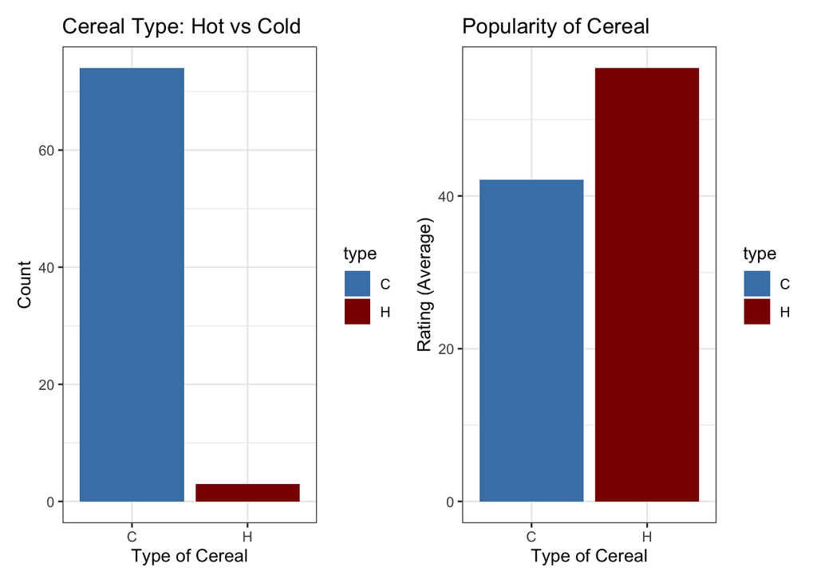

```r
fig1 <- ggplot(data=breakfast_data, aes(type, fill = type)) +
  geom_bar() +
  scale_fill_manual(values = c('steelblue', 'darkred')) +
  theme_bw() +
  xlab('Type of Cereal') +
  ylab('Count') +
  ggtitle('Cereal Type: Hot vs Cold')

group_type_rating <- breakfast_data %>%
  group_by(type) %>%
  summarise(rating = mean(rating))

fig2 <- ggplot(data=group_type_rating, aes(x=type, y=rating, fill = type)) +
  geom_col() +
  scale_fill_manual(values = c('steelblue', 'darkred')) +
  xlab('Type of Cereal') +
  ylab('Rating (Average)') +
  theme_bw() +
  ggtitle('Popularity of Cereal')

fig1 + fig2
```

- With the first bar chart, we can see that there a lot more cold cereals than the hot ones. In conjunction with the second barchart, we see the ratings of these type of cereals, and can see that based on the market data we have, hot cereals are rated higher than the cold cereals.
- A takeaway from this would be that introducing a new ‘HOT’ cereal would be a good idea for PostNabico.

### Density plots of all the important nutrients

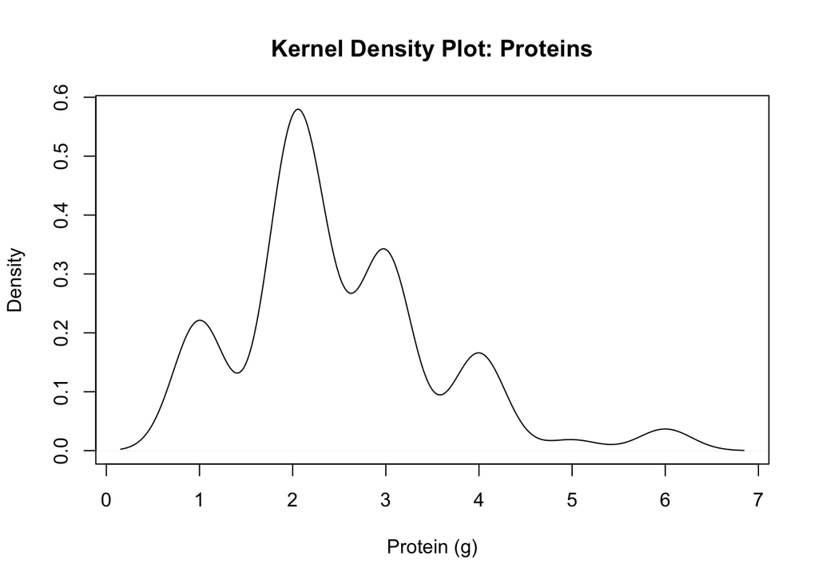

```r
protein_dist <- plot(density(breakfast_data$protein),
                     main = 'Kernel Density Plot: Proteins',
                     xlab = 'Protein (g)',
                     ylab = 'Density')
```

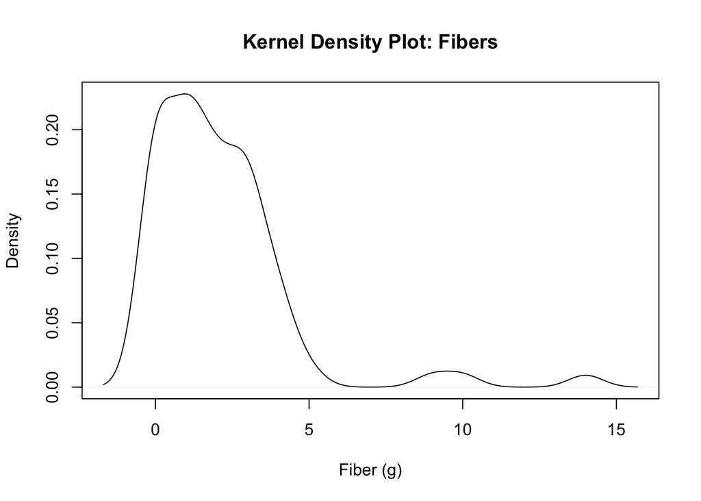

```r
fiber_dist <- plot(density(breakfast_data$fiber),
                     main = 'Kernel Density Plot: Fibers',
                     xlab = 'Fiber (g)',
                     ylab = 'Density')
```

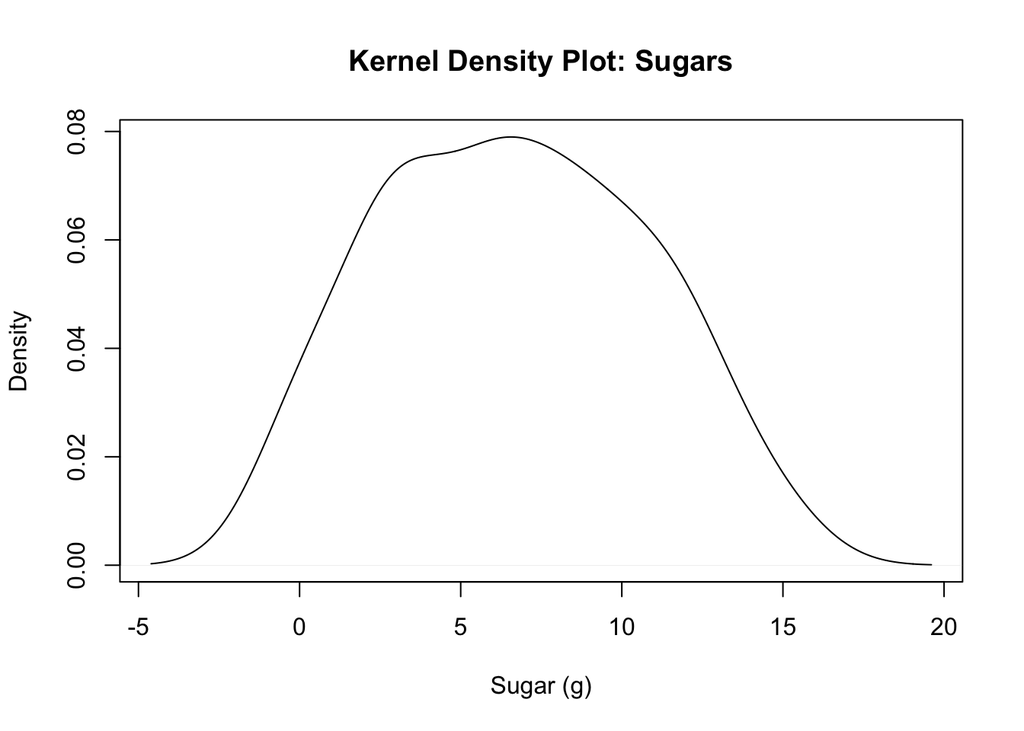

```r
sugar_dist <- plot(density(breakfast_data$sugars),
                     main = 'Kernel Density Plot: Sugars',
                     xlab = 'Sugar (g)',
                     ylab = 'Density')
```

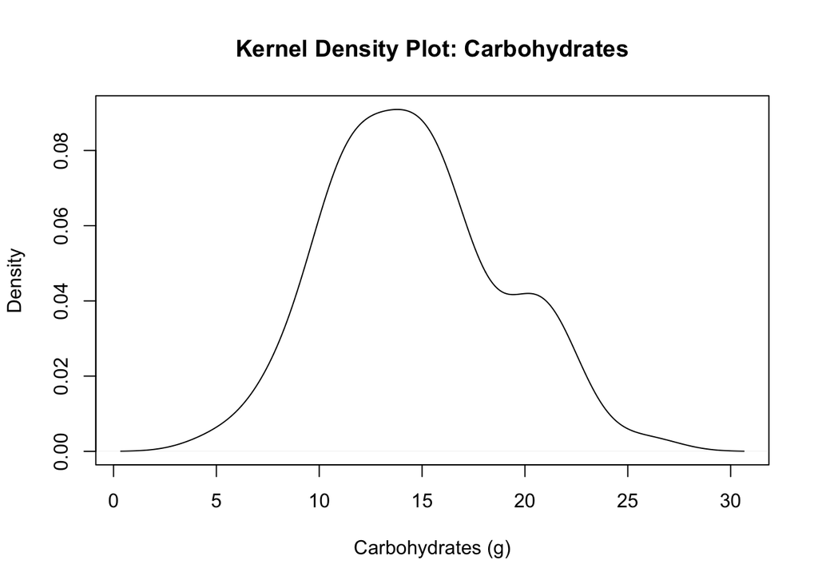

```r
carbo_dist <- plot(density(breakfast_data$carbo),
                     main = 'Kernel Density Plot: Carbohydrates',
                     xlab = 'Carbohydrates (g)',
                     ylab = 'Density')
```

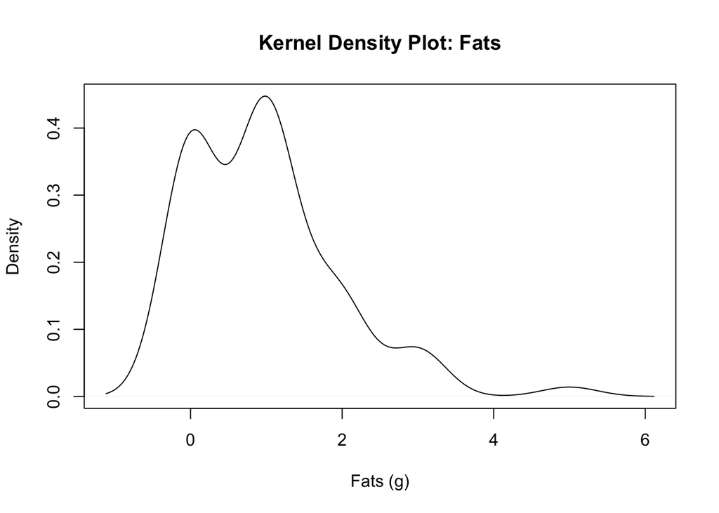

```r
fat_dist <- plot(density(breakfast_data$fat),
                     main = 'Kernel Density Plot: Fats',
                     xlab = 'Fats (g)',
                     ylab = 'Density')
```

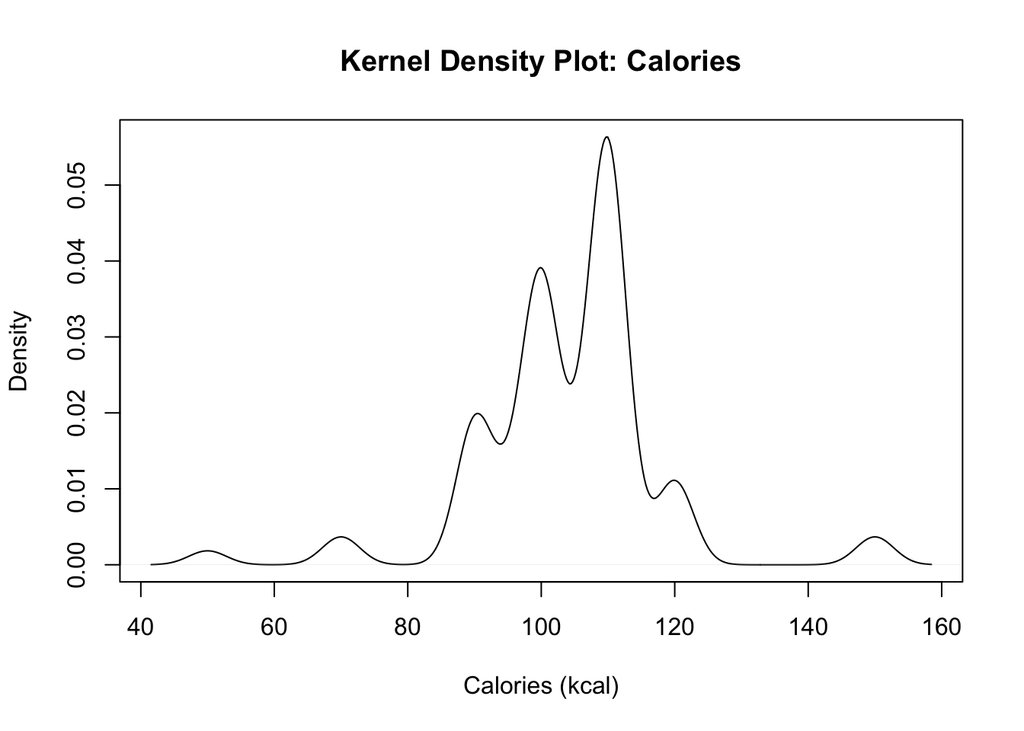

```r
calories_dist <- plot(density(breakfast_data$calories),
                     main = 'Kernel Density Plot: Calories',
                     xlab = 'Calories (kcal)',
                     ylab = 'Density')
```

- The most common measures of center are the mean and the median.
- Generally, if the distribution is not symmetrical and shows skewness, we use the median as the measure of center instead of using the mean since the mean is susceptible to changes with abnormalities in the data (eg. skewness, symmetry, and outliers) and cannot be a good representation of the center.
- Thus, on observing the density plots for different nutrients, we chose to use mean for sugars, carbohydrates, calories and median for the others.

### Statistics of the important nutrients

```r
paste("Median of Protein = ",median(breakfast_data$protein))
```

```
## [1] "Median of Protein =  2.25563909774436"
```

```r
paste("Median of Fiber = ", median(breakfast_data$fiber))
```

```
## [1] "Median of Fiber =  1.53846153846154"
```

```r
paste("Medn of Sugars = ", mean(breakfast_data$sugars))
```

```
## [1] "Medn of Sugars =  6.65837375201695"
```

```r
paste("Mean of Carbohydrates = ", mean(breakfast_data$carbo))
```

```
## [1] "Mean of Carbohydrates =  14.6251828089667"
```

```r
paste("Median of Fats = ", median(breakfast_data$fat))
```

```
## [1] "Median of Fats =  1"
```

```r
paste("Median of Calories = ", mean(breakfast_data$calories))
```

[output not shown]

### Creating categorical variables (High/Low) for classification based on Nutrients

```r
breakfast_data <- breakfast_data %>%
  mutate(protein_class = case_when(
    protein > median(protein) ~ "High",
    protein <= median(protein) ~ "Low"
    ))

breakfast_data <- breakfast_data %>%
  mutate(fiber_class = case_when(
    fiber > median(fiber) ~ "High",
    fiber <= median(fiber) ~ "Low"
    ))

breakfast_data <- breakfast_data %>%
  mutate(carbo_class = case_when(
    carbo > mean(carbo) ~ "High",
    carbo <= mean(carbo) ~ "Low"
    ))

breakfast_data <- breakfast_data %>%
  mutate(sugars_class = case_when(
    sugars > mean(sugars) ~ "High",
    sugars <= mean(sugars) ~ "Low"
    ))

breakfast_data <- breakfast_data %>%
  mutate(fat_class = case_when(
    fat > median(fat) ~ "High",
    fat <= median(fat) ~ "Low"
    ))

breakfast_data <- breakfast_data %>%
  mutate(calories_class = case_when(
    calories > mean(calories) ~ "High",
    calories <= mean(calories) ~ "Low"
    ))
```

- Since we do not have any external data that talks about what high levels and low levels should be, we took the measures of centers for the nutrients and made them our ‘zero’ points.
- Any value greater than this ‘zero’ point was considered high, and the values lesser were classified as low.

### Classification plots based on nutrients

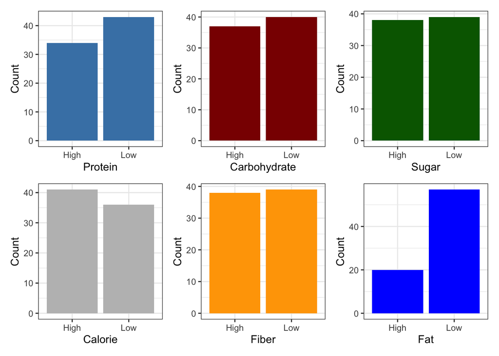

```r
fig3 <- ggplot(data=breakfast_data, aes(protein_class)) +
  geom_bar(fill = 'steelblue') +
  theme_bw() +
  ylab('Count') +
  xlab('Protein')

fig4 <- ggplot(data=breakfast_data, aes(carbo_class)) +
  geom_bar(fill = 'darkred') +
  theme_bw() +
  ylab('Count') +
  xlab('Carbohydrate')

fig5 <- ggplot(data=breakfast_data, aes(sugars_class)) +
  geom_bar(fill = 'darkgreen') +
  theme_bw() +
  ylab('Count') +
  xlab('Sugar')

fig6 <- ggplot(data=breakfast_data, aes(calories_class)) +
  geom_bar(fill = 'grey') +
  theme_bw() +
  ylab('Count') +
  xlab('Calorie')

fig7 <- ggplot(data=breakfast_data, aes(fiber_class)) +
  geom_bar(fill = 'orange') +
  theme_bw() +
  ylab('Count') +
  xlab('Fiber')

fig8 <- ggplot(data=breakfast_data, aes(fat_class)) +
  geom_bar(fill = 'blue') +
  theme_bw() +
  ylab('Count') +
  xlab('Fat')

fig3 + fig4 + fig5 + fig6 + fig7 + fig8
```

- Carbohydrates, sugar, fiber have a comparable count between different categories, but in case of protein, calories, fat, we can see a clear distinction between the count of the categories.

### Feature engineering to form new columns

```r
breakfast_data <- breakfast_data %>%
  mutate(Healthy = ifelse(sugars_class == "Low" &
                          fiber_class == 'High', "Healthy", "Unhealthy"),
         Keto = ifelse(carbo_class == "Low" &
                       fat_class == "High", "Yes", "No"))
```

- If a cereal is low in sugar and high in fiber, it is classified as a healthy cereal.
- If a cereal is low in carbohydrates and high in fat, it is classified as a keto-friendly cereal.
- We did not take other factors such as fat into consideration to decide whether a cereal is healthy or not because if you go out to buy a cereal, you’d only look at the sugar value and the fiber value to make the choice. So these two factors were enough to classify. Moreover, taking more factors into account was generating a strict combination, resulting in a few healthy options only.

### Bar plot to count the number of healthy/keto options colored by whether they are keto friendly/healthy or not

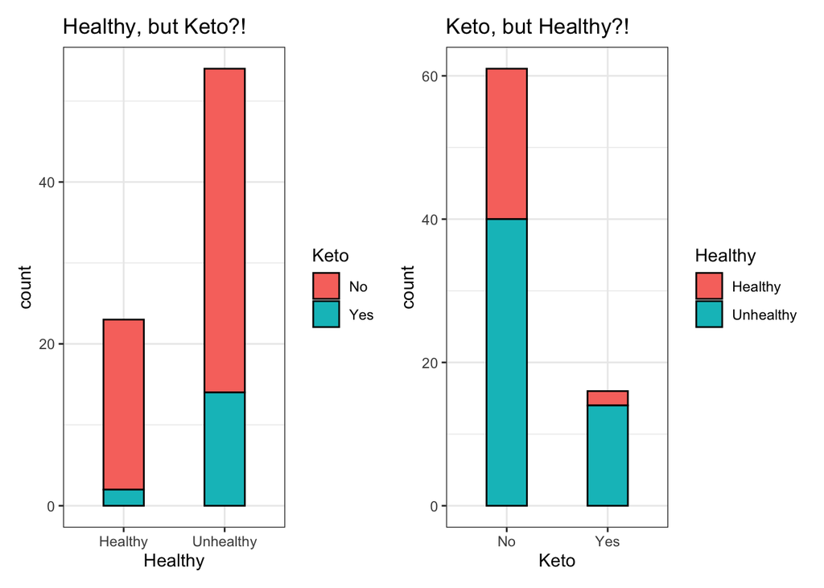

```r
fig9 <- ggplot(data = breakfast_data, mapping = aes(Healthy)) +
  geom_bar(mapping = aes(fill = Keto), width = 0.4, color = 'black') +
  theme_bw() +
  ggtitle('Healthy, but Keto?!')

fig10 <- ggplot(data = breakfast_data, mapping = aes(Keto)) +
  geom_bar(mapping = aes(fill = Healthy), width = 0.4, color = 'black') +
  theme_bw() +
  ggtitle('Keto, but Healthy?!')

fig9 + fig10
```

- We have a lot more unhealthy options on the shelves right now. Keto-friendly options are also nowhere to be seen as compared to the non keto-friendly versions. It might be a good idea to jump in either of these less-crowded sectors and try to specialize in these areas.

### Scatter plots to get the distribution of ratings classified by healthy/unhealthy/keto/not keto

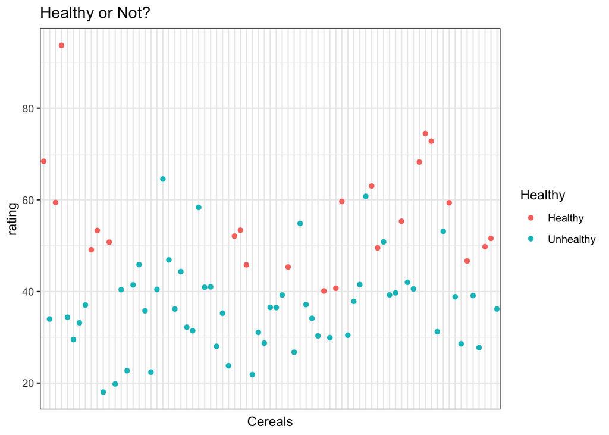

```r
fig11 <- ggplot(data = breakfast_data, mapping = aes(x = name, y = rating)) +
  geom_point(aes(color = Healthy)) +
  theme_bw() +
  theme(axis.text.x = element_blank(),
        axis.ticks.x = element_blank()) +
  xlab('Cereals') +
  ggtitle("Healthy or Not?")

fig12 <- ggplot(data = breakfast_data, mapping = aes(x = name, y = rating)) +
  geom_point(aes(color = Keto)) +
  theme_bw() +
  theme(axis.text.x = element_blank(),
        axis.ticks.x = element_blank()) +
  xlab('Cereals') +
  ggtitle("Keto or Not?")

fig13 <- ggplot(data = breakfast_data, mapping = aes(x = name, y = rating)) +
  geom_point(aes(color = type)) +
  theme_bw() +
  theme(axis.text.x = element_blank(),
        axis.ticks.x = element_blank()) +
  xlab('Cereals') +
  ggtitle("Hot or Cold?")

fig14 <- ggplot(data = breakfast_data, mapping = aes(x = name, y = rating)) +
  geom_point(aes(color = calories_class)) +
  theme_bw() +
  theme(axis.text.x = element_blank(),
        axis.ticks.x = element_blank()) +
  xlab('Cereals') +
  ggtitle("High-Cal or Low-Cal?")

fig11
```

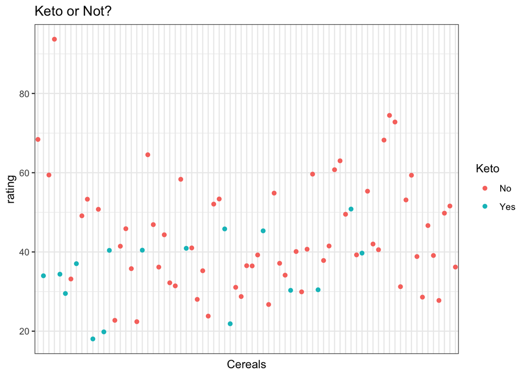

```r
fig12
```

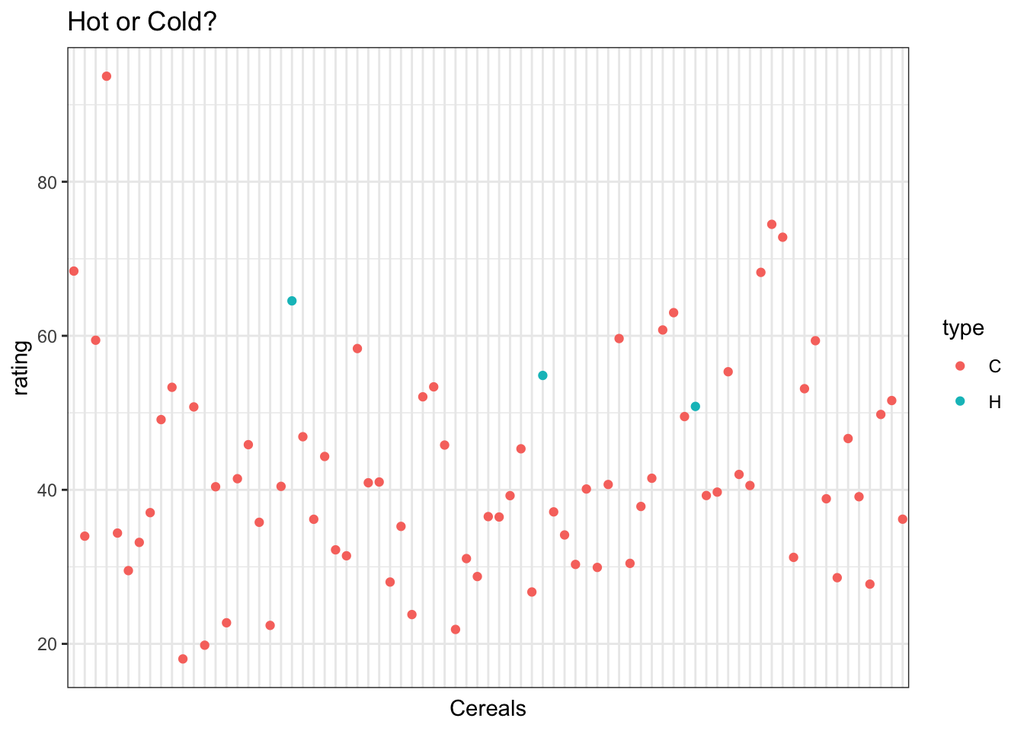

```r
fig13
```

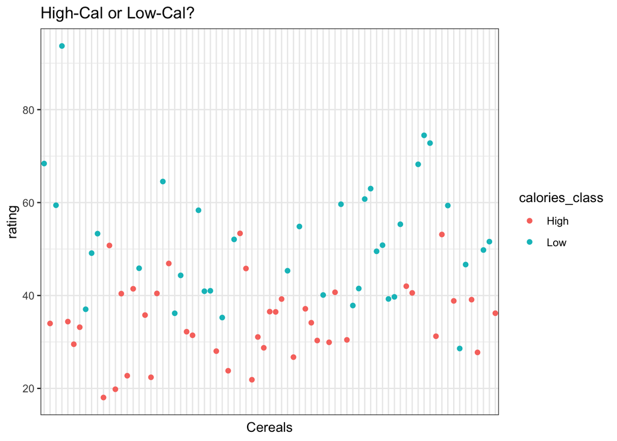

```r
fig14
```

- Healthy options have a better rating than the unhealthy options.
- Keto-friendly options do not make a good impression in the market. A valid reason would be that the consumers misconstrue a high fat content to be unfavourable in a cereal. Labeling the cereal explicitly as ‘Keto-Friendly’ may mitigate this problem.
- Hot cereals have a really small presence in the current RTE breakfast cereal market and they receive a good rating by the consumers. Thus, it would be a good time to introduce a new ‘Hot’ Cereal into the market.
- It is pretty evident from the scatterplot that the Low-Calorie cereals have a better rating and thus perform better in the cereal market.

### Histograms of the distribution of different nutrients on the basis of the manufacturers

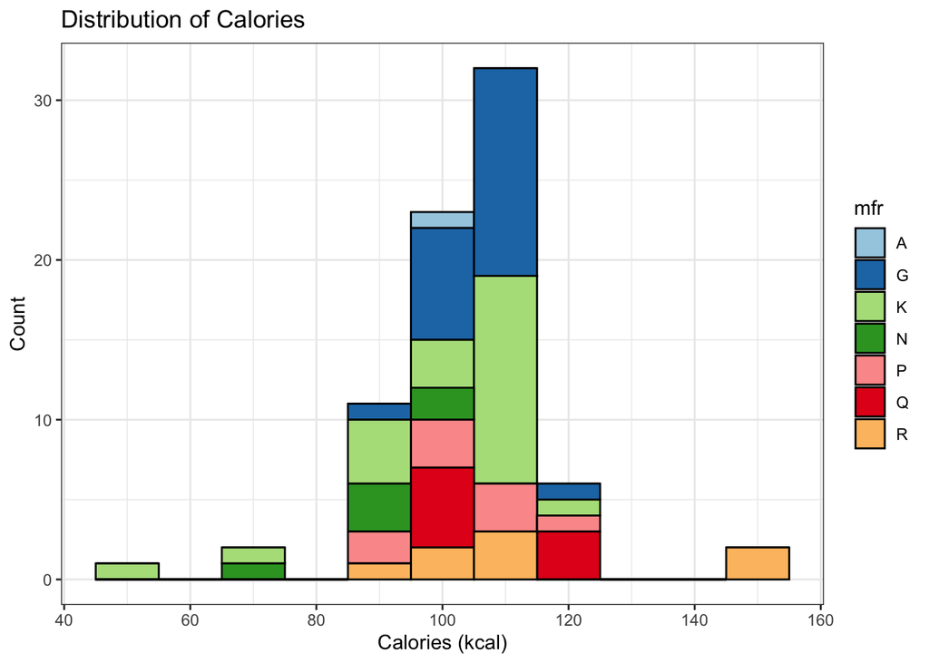

```r
cal_gg <- ggplot(data=breakfast_data, aes(calories)) +
  geom_histogram(aes(fill=mfr), color = 'black', binwidth = 10) +
  scale_fill_brewer(palette = "Paired") +
  theme_bw() +
  xlab("Calories (kcal)") +
  ylab('Count') +
  ggtitle('Distribution of Calories')

prot_gg <- ggplot(data=breakfast_data, aes(protein)) +
  geom_histogram(aes(fill=mfr), color = 'black', binwidth = 1) +
  scale_fill_brewer(palette = "Paired") +
  theme_bw() +
  xlab("Protein (g)") +
  ylab('Count') +
  ggtitle('Distribution of Protein')

fib_gg <- ggplot(data=breakfast_data, aes(fiber)) +
  geom_histogram(aes(fill=mfr), color = 'black', binwidth = 0.5) +
  scale_fill_brewer(palette = "Paired") +
  theme_bw() +
  xlab("Fiber (g)") +
  ylab('Count') +
  ggtitle('Distribution of Fiber')

carbo_gg <- ggplot(data=breakfast_data, aes(carbo)) +
  geom_histogram(aes(fill=mfr), color = 'black', binwidth = 1) +
  scale_fill_brewer(palette = "Paired") +
  theme_bw() +
  xlab("Carbohydrates (g)") +
  ylab('Count') +
  ggtitle('Distribution of Carbohydrates')

sug_gg <- ggplot(data=breakfast_data, aes(sugars)) +
  geom_histogram(aes(fill=mfr), color = 'black', binwidth = 1) +
  scale_fill_brewer(palette = "Paired") +
  theme_bw() +
  xlab("Sugars (g)") +
  ylab('Count') +
  ggtitle('Distribution of Sugars')

rating_ave <- breakfast_data %>% group_by(mfr) %>%
  summarise(rating = mean(rating))

rat_gg <- ggplot(data=rating_ave, aes(x=mfr, y=rating)) +
  geom_col(mapping=aes(fill=mfr), color = 'black') +
  scale_fill_brewer(palette = "Paired") +
  theme_bw() +
  xlab("Manufacturers") +
  ylab('Rating') +
  ggtitle('Average Ratings')

type_gg <- ggplot(data=breakfast_data, aes(type, fill = mfr)) +
  geom_bar(color = 'black', width = 0.4) +
  scale_fill_brewer(palette = "Paired") +
  theme_bw() +
  xlab('Type of Cereal') +
  ylab('Count') +
  ggtitle('Cereal Type: Hot vs Cold')

sod_gg <- ggplot(data=breakfast_data, aes(sodium, fill = mfr)) +
  geom_histogram(aes(fill=mfr), color = 'black') +
  scale_fill_brewer(palette = "Paired") +
  theme_bw() +
  xlab('Sodium (mg)') +
  ylab('Count') +
  ggtitle('Distibution of Sodium')

pot_gg <- ggplot(data=breakfast_data, aes(potass, fill = mfr)) +
  geom_histogram(aes(fill=mfr), color = 'black') +
  scale_fill_brewer(palette = "Paired") +
  theme_bw() +
  xlab('Potassium (mg)') +
  ylab('Count') +
  ggtitle('Distibution of Potassium')

vit_gg <- ggplot(data=breakfast_data, aes(vitamins, fill = mfr)) +
  geom_histogram(aes(fill=mfr), color = 'black') +
  scale_fill_brewer(palette = "Paired") +
  theme_bw() +
  xlab('Vitamins (mcg)') +
  ylab('Count') +
  ggtitle('Distibution of Vitamins')

fat_gg <- ggplot(data=breakfast_data, aes(fat, fill = mfr)) +
  geom_histogram(aes(fill=mfr), color = 'black', binwidth = 1) +
  scale_fill_brewer(palette = "Paired") +
  theme_bw() +
  xlab('Fats (g)') +
  ylab('Count') +
  ggtitle('Distibution of Fats')

cal_gg
```

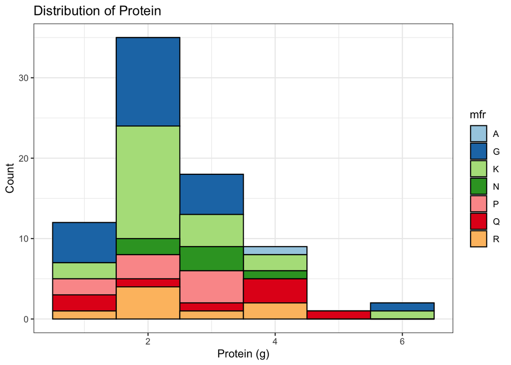

```r
prot_gg
```

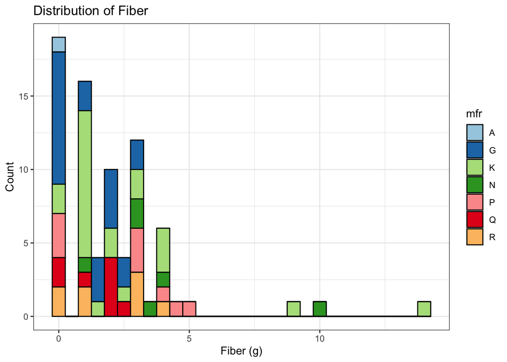

```r
fib_gg
```

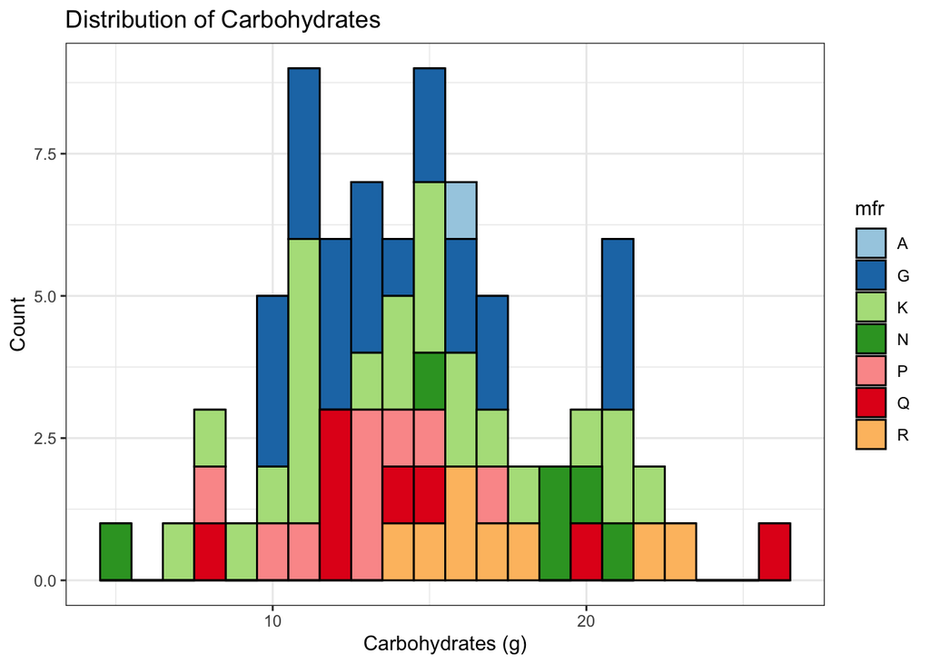

```r
carbo_gg
```

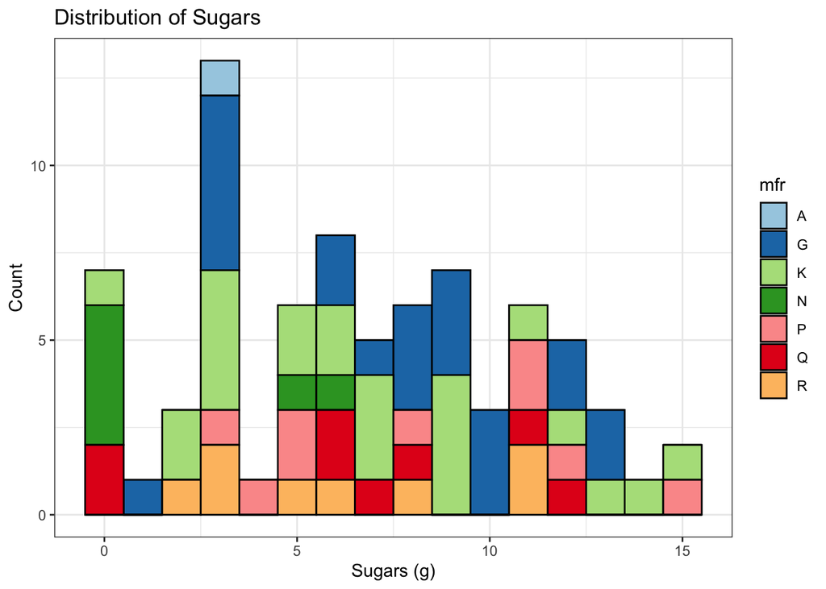

```r
sug_gg
```

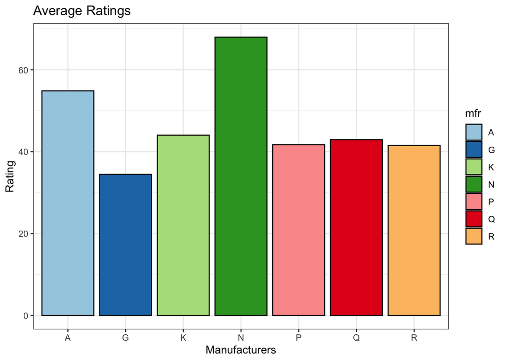

```r
rat_gg
```

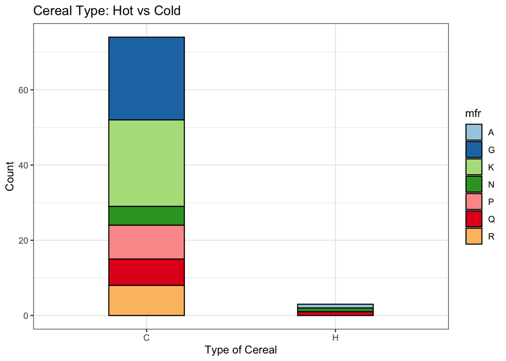

```r
type_gg
```

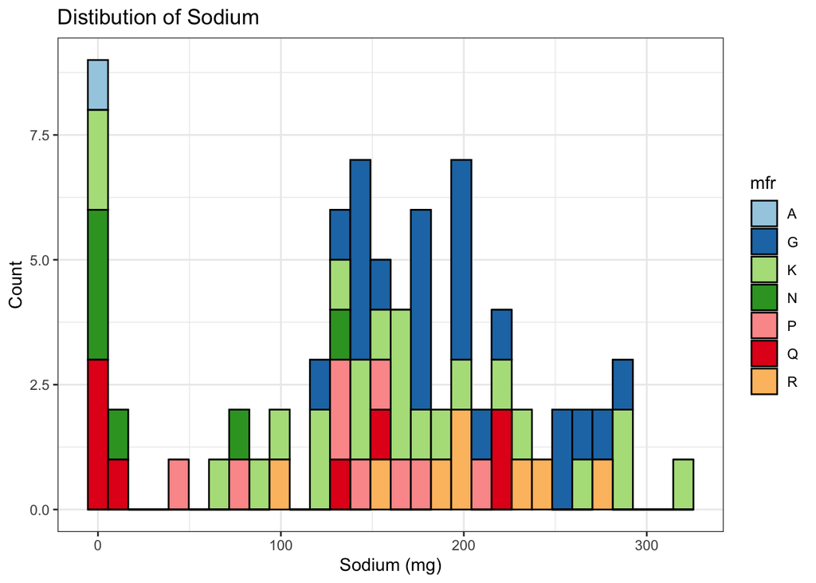

```r
sod_gg
```

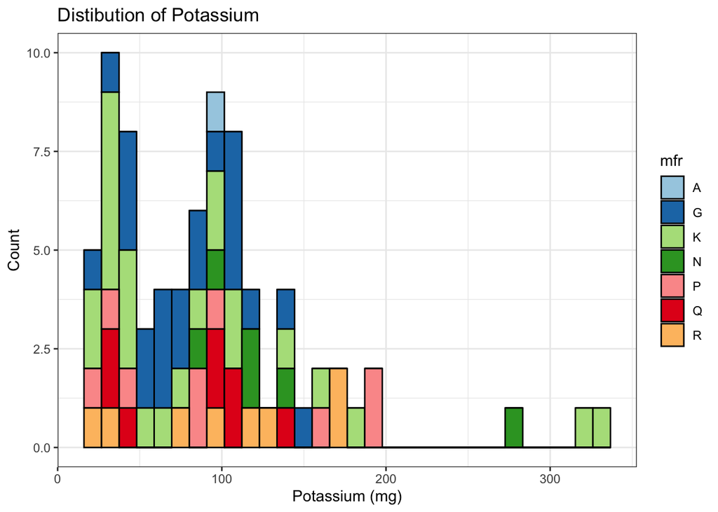

```r
pot_gg
```

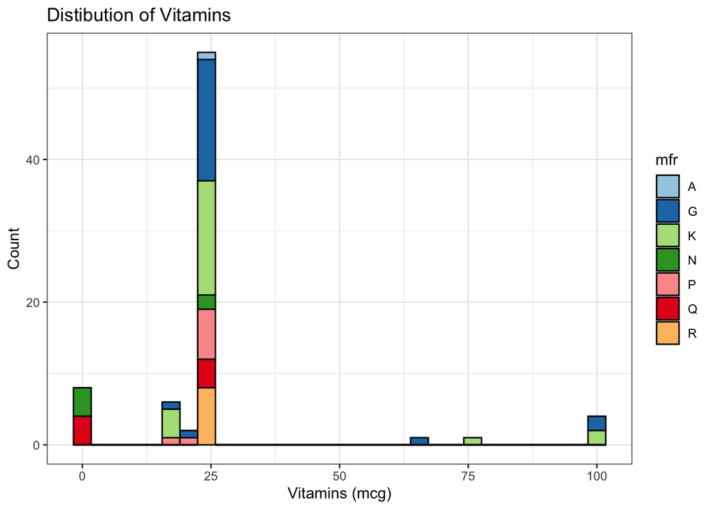

```r
vit_gg
```

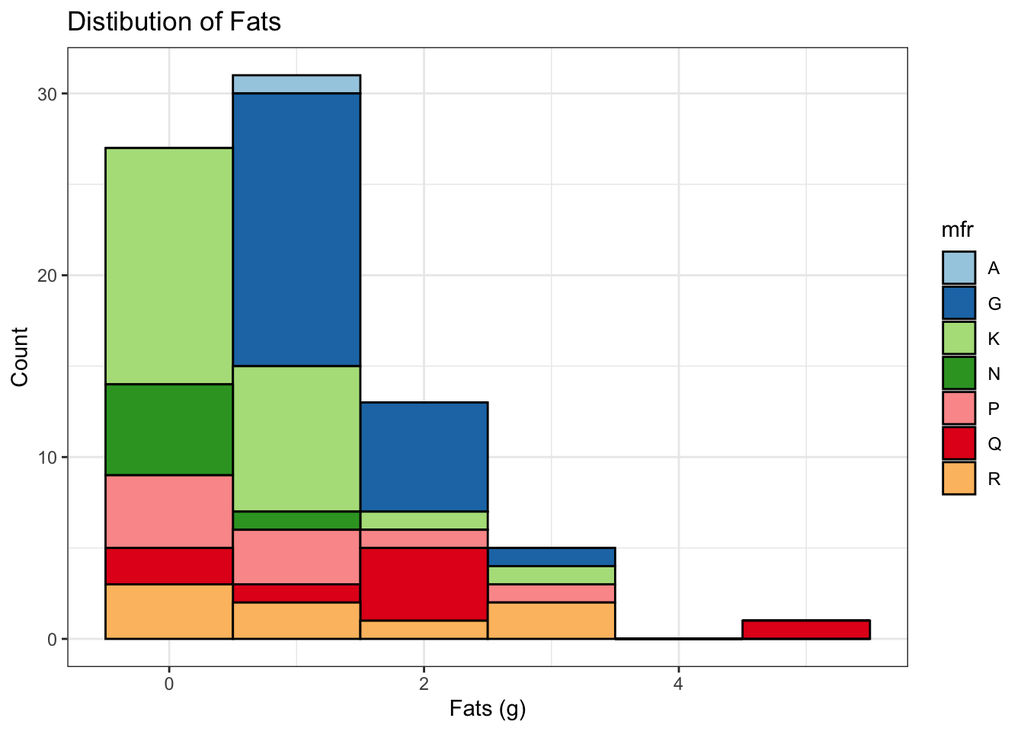

```r
fat_gg
```

### Bar chart to show the count of keto friendly options segregated by the manufacturers

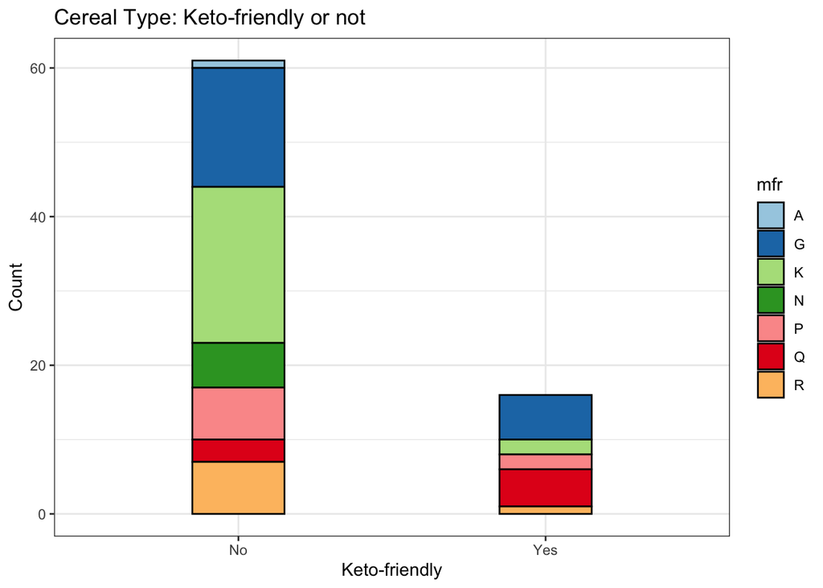

```r
keto_gg <- ggplot(data=breakfast_data, aes(Keto, fill = mfr)) +
  geom_bar(width = 0.3, colour = 'black') +
  scale_fill_brewer(palette = "Paired") +
  theme_bw() +
  xlab('Keto-friendly') +
  ylab('Count') +
  ggtitle('Cereal Type: Keto-friendly or not')

keto_gg
```

- Keto-friendly options do not have a particularly good reputation in the market, especially companies like Quaker Oats, and General Mills which produce products having the worst ratings in the Keto-friendly segment. So we can compete with these companies by coming up with better Keto-options in the RTE breakfast cereal market as another opportunity to cause a dent in the rival firm’s market shares.

### Pie chart to show the proportion of cereals on each shelf

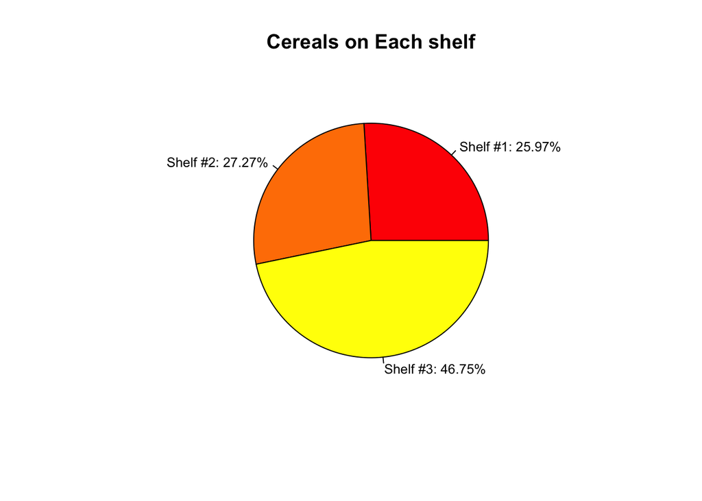

```r
# calculating total number of breakfast_data on each shelf
shelf1 <- breakfast_data[breakfast_data$shelf == 1,]
num_shelf1 <- nrow(shelf1)


shelf2 <- breakfast_data[breakfast_data$shelf == 2,]
num_shelf2 <- nrow(shelf2)


shelf3 <- breakfast_data[breakfast_data$shelf == 3,]
num_shelf3 <- nrow(shelf3)


# calculating total number of breakfast_data
total <- num_shelf1 + num_shelf2 + num_shelf3


# proportion of breakfast_data on each shelf
prop_shelf1 <- num_shelf1 / total


prop_shelf2 <- num_shelf2 / total


prop_shelf3 <- num_shelf3 / total


# creating data frame of quantities and proportion on each shelf
num_shelves <- c(num_shelf1, num_shelf2, num_shelf3)
percentage <- c(round(prop_shelf1,4)*100, round(prop_shelf2,4)*100, round(prop_shelf3,4)*100)

shelf_quantities <- as.data.frame(cbind(sort(unique(breakfast_data$shelf)), num_shelves, percentage))
colnames(shelf_quantities) <- c("shelf", "Quantity", "Percentage")

# creating labels for pie chart
lbl<-paste("Shelf #", shelf_quantities$shelf,": ", shelf_quantities$Percentage,"%",sep="")

# creating pie chart
pie(shelf_quantities$Quantity,
    labels = lbl,
    cex=0.8,
    col=heat.colors(length(shelf_quantities$Quantity)),
    main="Cereals on Each shelf")
```

- Approximately 50% of cereals are placed on Shelf 3 (startimg from the ground), followed by Shelf 2 and Shelf 1 which contain nearly the smae amount of cereal boxes.

[figure not shown]

```r
rating_shelf_med <- breakfast_data %>% group_by(shelf) %>%
  summarise(rating = mean(rating))

shelf_rat_gg <- ggplot(data=rating_shelf_med, aes(x=shelf, y=rating, fill=factor(shelf))) +
  geom_col(color = 'black') +
  scale_fill_brewer(palette = "Paired") +
  theme_bw() +
  xlab("Shelf") +
  ylab('Median Rating') +
  ggtitle('Median ratings over shelf')

shelf_rat_gg
```

- Here, we cannot make any concrete statements about the effect of shelf on the ratings of the cereals as we do not observe any significant difference in the ratings. We could make find a more meaningful insight if we were also given the sales data of these cereals.

## Limitations:

- The dataset only had 77 rows which contributed to finding approximated answers.
- Having more columns like sales, demand, prices, demographics, target consumers, and consumption would have contributed towards a better foundation for our analysis.
- A cereal with high carbohydrates can not be outrightly considered to be unhealthy because in case of cereals, whole grains and fibers are the major contributors to the carbohydrates.
- If a cereal has high amounts of fat, it does not necessarily mean that it is unhealthy because it also depends on the type of fat that is present.

## Future Scope:

- This project concentrated explicitly on demonstrating Data Visualizations for an audience having little-to-no statistic/economic background causing the analysis to be lucid but rudimentary.
- Deploying Machine Learning techniques such as Regressions, K-Means, and Cross Validation would result in producing more desirable deliverables.